# Initial Analysis

Let’s look at the variables of interest. These are crime index-total, crime index-violent, crime index-property, and green measures.

```r
skimr::skim(df$CRMCYTOTC)
```

```
Skim summary statistics

Variable type: integer
     variable missing complete     n   mean    sd p0 p25 median p75 p100     hist
 df$CRMCYTOTC       0    62086 62086 142.72 96.44  3  70    123 196 1232 ▇▃▁▁▁▁▁▁
```

```r
skimr::skim(df$CRMCYPERC)
```

```
Skim summary statistics

Variable type: integer
     variable missing complete     n  mean     sd p0 p25 median p75 p100     hist
 df$CRMCYPERC       0    62086 62086 183.2 164.23  2  60    134 258 1548 ▇▃▁▁▁▁▁▁
```

```r
skimr::skim(df$CRMCYPROC)
```

```
Skim summary statistics

Variable type: integer
     variable missing complete     n   mean    sd p0 p25 median p75 p100     hist
 df$CRMCYPROC       0    62086 62086 137.11 93.97  3  67    118 188 1318 ▇▃▁▁▁▁▁▁
```

```r
skimr::skim(df$ndvi_mean_cbg_adj)
```

```
Skim summary statistics

Variable type: numeric
             variable missing complete     n mean   sd   p0  p25 median p75 p100     hist
 df$ndvi_mean_cbg_adj       0    62086 62086 4.06 1.52 0.51 2.76   4.14 5.3 8.06 ▁▆▇▆▇▇▃▁
```

First, is there variation in the variables that is attributable to the differences between cities, the level 2 ‘groups’.

```r
t <- df[, c("CRMCYTOTC", "CRMCYPERC", "CRMCYPROC", "ndvi_mean_cbg_adj")]
mult.icc(as.data.frame(t), grpid= df$city_st)
```

| Variable | ICC1 | ICC2 |
| --- | --- | --- |
| CRMCYTOTC | 0.3062623 | 0.9891375 |
| CRMCYPERC | 0.3146686 | 0.9895514 |
| CRMCYPROC | 0.3056347 | 0.9891057 |
| ndvi_mean_cbg_adj | 0.6809065 | 0.9977332 |

Start with the intercept only models

```r
stargazer::stargazer(mod_1a, mod_1b, mod_1c, type = "text")
```

```
==========================================================
                             Dependent variable:
                    --------------------------------------
                     CRMCYTOTC    CRMCYPERC    CRMCYPROC
                        (1)          (2)          (3)
----------------------------------------------------------
Constant             136.188***   146.107***   134.813***
                      (3.103)      (5.247)      (3.012)

----------------------------------------------------------
Observations           62,086       62,086       62,086
Log Likelihood      -360,881.300 -392,292.300 -359,109.400
Akaike Inf. Crit.   721,768.700  784,590.600  718,224.800
Bayesian Inf. Crit. 721,795.800  784,617.800  718,251.900
==========================================================
Note:                          *p<0.1; **p<0.05; ***p<0.01
```

So maybe at this point let’s just look at the ndvi relationship. First as just random intercepts.

```r
mod_2a <- lmer(CRMCYTOTC ~ ndvi_mean_cbg_adj + (1|city_st), data = df)
mod_2b <- lmer(CRMCYPERC ~ ndvi_mean_cbg_adj + (1|city_st), data = df)
mod_2c <- lmer(CRMCYPROC ~ ndvi_mean_cbg_adj + (1|city_st), data = df)
stargazer::stargazer(mod_2a, mod_2b, mod_2c, type = "text")
```

```
==========================================================
                             Dependent variable:
                    --------------------------------------
                     CRMCYTOTC    CRMCYPERC    CRMCYPROC
                        (1)          (2)          (3)
----------------------------------------------------------
ndvi_mean_cbg_adj    -35.832***   -35.646***   -35.829***
                      (0.348)      (0.607)      (0.337)

Constant             290.346***   299.473***   288.972***
                      (4.916)      (6.814)      (4.846)

----------------------------------------------------------
Observations           62,086       62,086       62,086
Log Likelihood      -356,048.200 -390,624.400 -353,970.900
Akaike Inf. Crit.   712,104.400  781,256.900  707,949.700
Bayesian Inf. Crit. 712,140.600  781,293.000  707,985.900
==========================================================
Note:                          *p<0.1; **p<0.05; ***p<0.01
```

Do these fit better than the intercept only models?

```r
anova(mod_1a, mod_2a)
```

```
refitting model(s) with ML (instead of REML)
```

```
Data: df
Models:
mod_1a: CRMCYTOTC ~ 1 + (1 | city_st)
mod_2a: CRMCYTOTC ~ ndvi_mean_cbg_adj + (1 | city_st)
       Df    AIC    BIC  logLik deviance  Chisq Chi Df Pr(>Chisq)
mod_1a  3 721773 721800 -360883   721767
mod_2a  4 712109 712145 -356051   712101 9665.7      1  < 2.2e-16 ***
---
Signif. codes:  0 ‘***’ 0.001 ‘**’ 0.01 ‘*’ 0.05 ‘.’ 0.1 ‘ ’ 1
```

```r
anova(mod_1b, mod_2b)
```

```
refitting model(s) with ML (instead of REML)
```

```
Data: df
Models:
mod_1b: CRMCYPERC ~ 1 + (1 | city_st)
mod_2b: CRMCYPERC ~ ndvi_mean_cbg_adj + (1 | city_st)
       Df    AIC    BIC  logLik deviance  Chisq Chi Df Pr(>Chisq)
mod_1b  3 784596 784623 -392295   784590
mod_2b  4 781263 781299 -390628   781255 3334.5      1  < 2.2e-16 ***
---
Signif. codes:  0 ‘***’ 0.001 ‘**’ 0.01 ‘*’ 0.05 ‘.’ 0.1 ‘ ’ 1
```

```r
anova(mod_1c, mod_2c)
```

```
refitting model(s) with ML (instead of REML)
```

```
Data: df
Models:
mod_1c: CRMCYPROC ~ 1 + (1 | city_st)
mod_2c: CRMCYPROC ~ ndvi_mean_cbg_adj + (1 | city_st)
       Df    AIC    BIC  logLik deviance Chisq Chi Df Pr(>Chisq)
mod_1c  3 718229 718256 -359111   718223
mod_2c  4 707954 707990 -353973   707946 10277      1  < 2.2e-16 ***
---
Signif. codes:  0 ‘***’ 0.001 ‘**’ 0.01 ‘*’ 0.05 ‘.’ 0.1 ‘ ’ 1
```

Next, how about adding random slopes for NDVI. Now the NDVI slope varies by city, so some cities will have a stronger or weaker relationship between NDVI and crime.

```r
mod_3a <- lmer(CRMCYTOTC ~ ndvi_mean_cbg_adj + (ndvi_mean_cbg_adj|city_st), data = df)
mod_3b <- lmer(CRMCYPERC ~ ndvi_mean_cbg_adj + (ndvi_mean_cbg_adj|city_st), data = df)
mod_3c <- lmer(CRMCYPROC ~ ndvi_mean_cbg_adj + (ndvi_mean_cbg_adj|city_st), data = df)
summary(mod_3a)
```

```
Linear mixed model fit by REML ['lmerMod']
Formula: CRMCYTOTC ~ ndvi_mean_cbg_adj + (ndvi_mean_cbg_adj | city_st)
   Data: df

REML criterion at convergence: 706716.9

Scaled residuals:
    Min      1Q  Median      3Q     Max
-4.9983 -0.6162 -0.0864  0.5229 14.2333

Random effects:
 Groups   Name              Variance Std.Dev. Corr
 city_st  (Intercept)       31703.8  178.06
          ndvi_mean_cbg_adj   631.2   25.12   -0.90
 Residual                    4962.2   70.44
Number of obs: 62086, groups:  city_st, 301

Fixed effects:
                  Estimate Std. Error t value
(Intercept)        344.447     10.587   32.53
ndvi_mean_cbg_adj  -45.482      1.568  -29.01

Correlation of Fixed Effects:
            (Intr)
ndv_mn_cbg_ -0.899
```

```r
summary(mod_3b)
```

```
Linear mixed model fit by REML ['lmerMod']
Formula: CRMCYPERC ~ ndvi_mean_cbg_adj + (ndvi_mean_cbg_adj | city_st)
   Data: df

REML criterion at convergence: 777672.6

Scaled residuals:
    Min      1Q  Median      3Q     Max
-4.1869 -0.5907 -0.1154  0.4570 11.1565

Random effects:
 Groups   Name              Variance Std.Dev. Corr
 city_st  (Intercept)       50910    225.63
          ndvi_mean_cbg_adj  1125     33.54   -0.86
 Residual                   15622    124.99
Number of obs: 62086, groups:  city_st, 301

Fixed effects:
                  Estimate Std. Error t value
(Intercept)        351.034     13.753   25.52
ndvi_mean_cbg_adj  -45.203      2.192  -20.62

Correlation of Fixed Effects:
            (Intr)
ndv_mn_cbg_ -0.867
```

```r
summary(mod_3c)
```

```
Linear mixed model fit by REML ['lmerMod']
Formula: CRMCYPROC ~ ndvi_mean_cbg_adj + (ndvi_mean_cbg_adj | city_st)
   Data: df

REML criterion at convergence: 702323.7

Scaled residuals:
    Min      1Q  Median      3Q     Max
-5.1835 -0.6027 -0.0872  0.5000 15.5106

Random effects:
 Groups   Name              Variance Std.Dev. Corr
 city_st  (Intercept)       32058.0  179.05
          ndvi_mean_cbg_adj   641.2   25.32   -0.91
 Residual                    4621.8   67.98
Number of obs: 62086, groups:  city_st, 301

Fixed effects:
                  Estimate Std. Error t value
(Intercept)        343.259     10.622   32.32
ndvi_mean_cbg_adj  -45.420      1.571  -28.91

Correlation of Fixed Effects:
            (Intr)
ndv_mn_cbg_ -0.908
```

Do the models with varying slopes provide a better fit?

```r
anova(mod_2a, mod_3a)
```

```
refitting model(s) with ML (instead of REML)
```

```
Data: df
Models:
mod_2a: CRMCYTOTC ~ ndvi_mean_cbg_adj + (1 | city_st)
mod_3a: CRMCYTOTC ~ ndvi_mean_cbg_adj + (ndvi_mean_cbg_adj | city_st)
       Df    AIC    BIC  logLik deviance  Chisq Chi Df Pr(>Chisq)
mod_2a  4 712109 712145 -356051   712101
mod_3a  6 706736 706791 -353362   706724 5376.6      2  < 2.2e-16 ***
---
Signif. codes:  0 ‘***’ 0.001 ‘**’ 0.01 ‘*’ 0.05 ‘.’ 0.1 ‘ ’ 1
```

```r
anova(mod_2b, mod_3b)
```

```
refitting model(s) with ML (instead of REML)
```

```
Data: df
Models:
mod_2b: CRMCYPERC ~ ndvi_mean_cbg_adj + (1 | city_st)
mod_3b: CRMCYPERC ~ ndvi_mean_cbg_adj + (ndvi_mean_cbg_adj | city_st)
       Df    AIC    BIC  logLik deviance  Chisq Chi Df Pr(>Chisq)
mod_2b  4 781263 781299 -390628   781255
mod_3b  6 777694 777748 -388841   777682 3573.5      2  < 2.2e-16 ***
---
Signif. codes:  0 ‘***’ 0.001 ‘**’ 0.01 ‘*’ 0.05 ‘.’ 0.1 ‘ ’ 1
```

```r
anova(mod_2c, mod_3c)
```

```
refitting model(s) with ML (instead of REML)
```

```
Data: df
Models:
mod_2c: CRMCYPROC ~ ndvi_mean_cbg_adj + (1 | city_st)
mod_3c: CRMCYPROC ~ ndvi_mean_cbg_adj + (ndvi_mean_cbg_adj | city_st)
       Df    AIC    BIC  logLik deviance Chisq Chi Df Pr(>Chisq)
mod_2c  4 707954 707990 -353973   707946
mod_3c  6 702343 702397 -351166   702331  5615      2  < 2.2e-16 ***
---
Signif. codes:  0 ‘***’ 0.001 ‘**’ 0.01 ‘*’ 0.05 ‘.’ 0.1 ‘ ’ 1
```

With allowing varying intercepts and slopes for NDVI we get an estimate for each city, let’s plot those from the 3rd models.

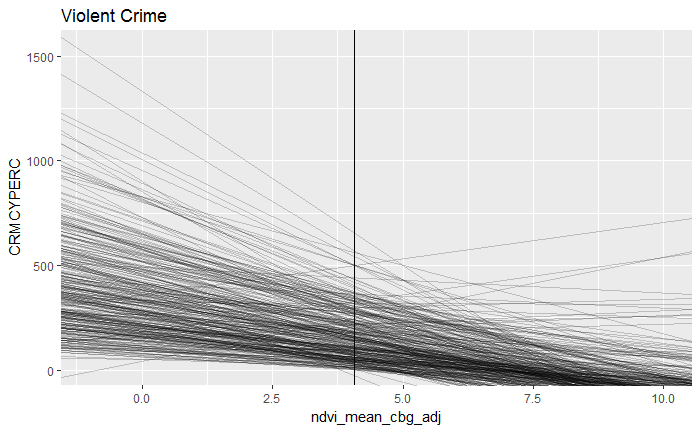

```r
estmod3b <- coef(mod_3b)$city_st
ggplot(df, aes(ndvi_mean_cbg_adj, CRMCYPERC)) + geom_point(alpha = 0) + geom_abline(data = estmod3b, aes(slope = ndvi_mean_cbg_adj, intercept = `(Intercept)`), alpha = .2) + xlim(-1, 10) + ggtitle("Violent Crime") + geom_vline(aes(xintercept = mean(ndvi_mean_cbg_adj)), data = df)
```

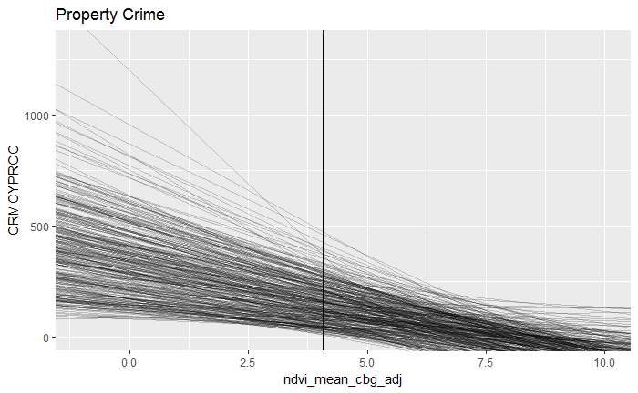

```r
estmod3c <- coef(mod_3c)$city_st
ggplot(df, aes(ndvi_mean_cbg_adj, CRMCYPROC)) + geom_point(alpha = 0) + geom_abline(data = estmod3c, aes(slope = ndvi_mean_cbg_adj, intercept = `(Intercept)`), alpha = .2) + xlim(-1, 10) + ggtitle("Property Crime") + geom_vline(aes(xintercept = mean(ndvi_mean_cbg_adj)), data = df)
```

Of course, to this point the IV has not been centered in any way. So the interpretation of the intercept term is the value of the DV when NDVI is 0, not terribly helpful right now.(min of NDVI in cbg is 0.5139746 and max of NDVI is 8.0595275)

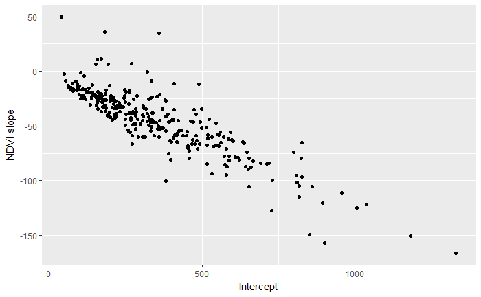

```r
estmod3b %>% mutate(city_st = row.names(.)) %>% ggplot(aes(`(Intercept)`, ndvi_mean_cbg_adj)) + geom_point() + labs(x = "Intercept", y = "NDVI slope")
```